# The stats::filter() function

Clay Ford

2022-10-12

The base R function `filter()` can be used to calculate moving averages. This is one of the base R functions masked when the {dplyr} package is loaded.

Before we see how it works, let’s create some toy data.

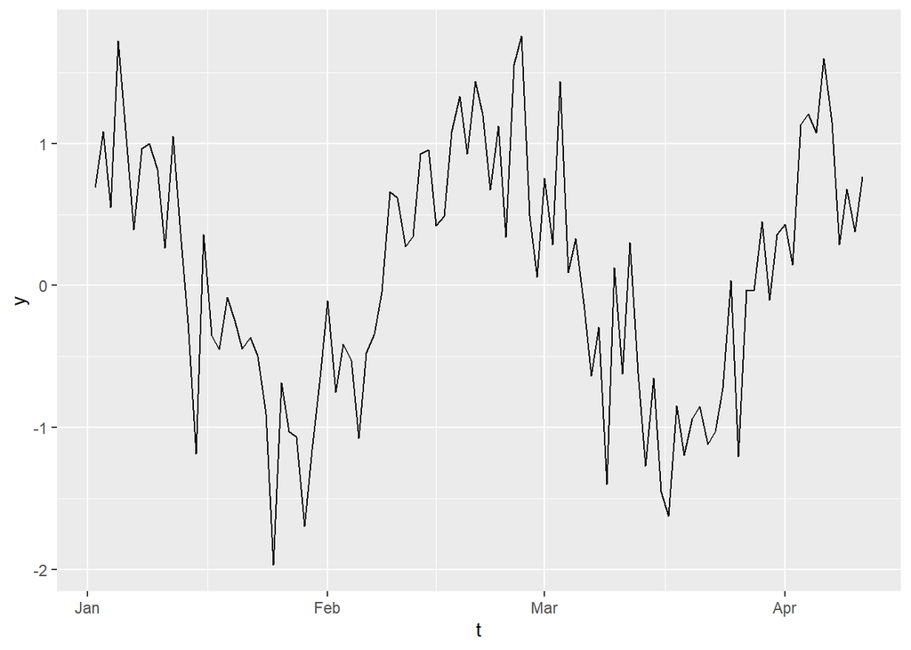

```r
n <- 100
t <- as.Date(seq(n), origin = as.Date("01/01/2022", "%m/%d/%Y"))
set.seed(1)
y <- cos(pi*seq(-2,2, length.out = n)) + rnorm(n, sd = 0.5)
d <- data.frame(t, y)

library(ggplot2)
ggplot(d) +
  aes(t, y) +
  geom_line()
```

## 3 day moving average

Let’s say we want to calculate a 3 day moving average. Two ways to approach this:

1. on any given day, take average of day before, current day, and next day. In other words use data from *both sides* of current day.
2. on any given day, take average of prior two days and current day. In other words use data from only *one side* of current day.

The first approach is the default of the `filter()` function. The first argument is the vector of data we want to calculate the moving average for. The second argument is the *filter* we want to apply to the data. These are *coefficients* we apply to the data before summing. For a 3 day moving average this is a vector of three `1/3`, which we can create using `rep(1/3, 3)`. The `sides=2` argument says use both sides of the data.

```r
d$ma3 <- stats::filter(d$y, filter = rep(1/3, 3), sides = 2)
```

Let’s look at the first three values. There’s a NA for day 1 because we have no data for the prior day.

```r
d$ma3[1:3]
```

```
## [1]        NA 0.7735613 1.1199731
```

The first 3 day moving average is 0.7735613 calculated at day 2. This is the average of days 1, 2, and 3.

```r
mean(y[1:3])
```

```
## [1] 0.7735613
```

Notice we can get the same result by multiplying each data point by `1/3`and summing. This is the “filter” applied to the data by the `filter()` function.

```r
sum(1/3 * y[1:3])
```

```
## [1] 0.7735613
```

One reason to calculate a moving average is to smooth out day-to-day variation. Below we plot the original data with the 3 day moving average superimposed.

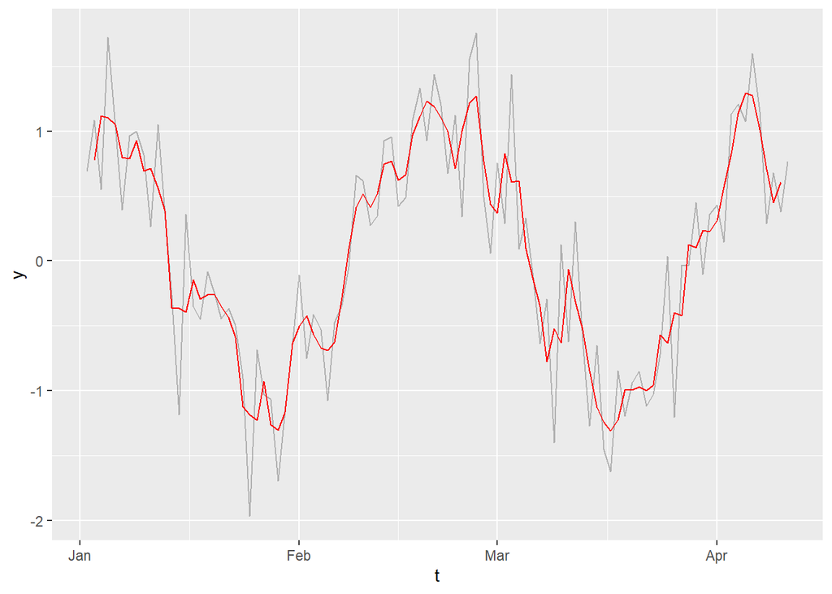

```r
ggplot(d) +
  aes(t, y) +
  geom_line(alpha = 1/4) +
  geom_line(aes(y = ma3), color  = "red")
```

The other approach is to use one side of the data. That means setting `sides= 1`. Now we get 2 NAs at the beginning because days 1 and 2 did not have two prior days.

```r
d$ma3 <- stats::filter(d$y, filter = rep(1/3, 3), sides = 1)
d$ma3[1:3]
```

```
## [1]        NA        NA 0.7735613
```

## odd versus even numbers

Odd numbers are good to use for `sides = 2` because we’ll get an equal number of days before and after the current day. If an even number is used, “more of the filter is forward in time than backward” (`?filter`).

For example, consider a 6 day moving average:

```r
d$ma6 <- stats::filter(d$y, filter = rep(1/6, 6), sides = 2)
d$ma6[1:3]
```

```
## [1]        NA        NA 0.9133886
```

The first 6 day moving average occurs at day 3 which is the average of the current day, the 2 previous days, and the 3 following days. Notice “more of the filter is *forward in time* than backward”:

1 2 **3** 4 5 6

```r
sum(1/6 * y[1:6])
```

```
## [1] 0.9133886
```

## Other functions

Three other functions for calculating moving averages are:

1. `runmean()` from the {caTools} package
2. `frollmean()` from the {data.table} package
3. `roll_mean()` from the {RcppRoll} package

Below I use all three to replicate the `stats::filter()` result.

For `caTools::runmean()` we need to specify `endrule = "NA"`, otherwise it uses an algorithm to calculate means in the extremes using smaller windows than 3.

For `data.table::frollmean()` we need to specify `align = "center"`, which is the same as `sides = 2` for `filter()`. Otherwise it defaults to `align = "right"` which is equivalent to `sides = 1` for `filter()`.

For `RcppRoll::roll_mean` we need to specify `fill = NA` to pad the output with missing values in the extremes. Otherwise, in this case, it returns a vector of length 98 instead of 100.

```r
d$ma3 <- stats::filter(d$y, filter = rep(1/3, 3), sides = 2)
d$ma3_runmean <- caTools::runmean(d$y, k = 3, endrule = "NA")
d$ma3_frollmean <- data.table::frollmean(d$y, n = 3, align = "center")
d$ma3_rcpproll <- RcppRoll::roll_mean(d$y, n = 3, align = "center",
                                      fill = NA)
head(d[,c("ma3", "ma3_runmean", "ma3_frollmean", "ma3_rcpproll")])
```

```
##         ma3 ma3_runmean ma3_frollmean ma3_rcpproll
## 1        NA          NA            NA           NA
## 2 0.7735613   0.7735613     0.7735613    0.7735613
## 3 1.1199731   1.1199731     1.1199731    1.1199731
## 4 1.1049153   1.1049153     1.1049153    1.1049153
## 5 1.0532159   1.0532159     1.0532159    1.0532159
## 6 0.8003626   0.8003626     0.8003626    0.8003626
```